# Chapter 5

Amanda P

1/17/2018

# 5.3.1 Exercises

1. The first two arguments to `ggplot` are `data` and `mapping`. The first two arguments to all layer functions are `mapping` and `data`. Why does the order of the arguments differ? (Hint: think about what you set most commonly.)

Most often we define the dataset in the `ggplot` function, which means that we most often will not need to define the data in the layer functions. The mapping is sometimes determined in `ggplot` and sometimes in the layer function.

2. The following code uses dplyr to generate some summary statistics about each class of car (you’ll learn how it works in Chapter 10).

```r
library(dplyr)
class <- mpg %>% group_by(class) %>% summarise(n=n(), hwy=mean(hwy))
class
```

```
## # A tibble: 7 x 3
##        class     n      hwy
##        <chr> <int>    <dbl>
## 1    2seater     5 24.80000
## 2    compact    47 28.29787
## 3    midsize    41 27.29268
## 4    minivan    11 22.36364
## 5     pickup    33 16.87879
## 6 subcompact    35 28.14286
## 7        suv    62 18.12903
```

Use the data to recreate the plot (shown in book).

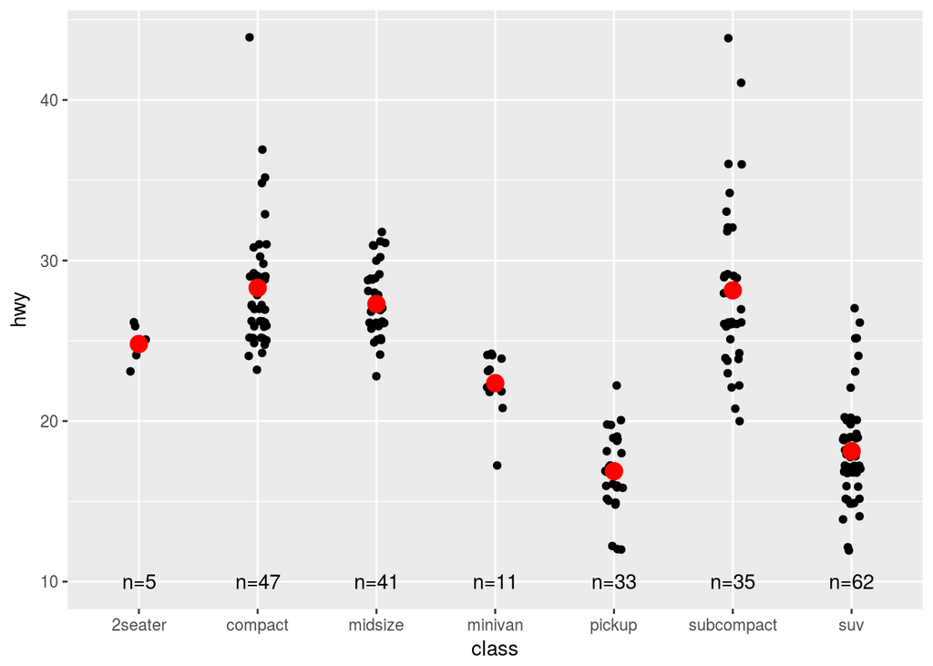

```r
ggplot(mpg,aes(class,hwy)) + geom_jitter(height=.25,width=.075) + geom_point(aes(class,hwy), data=class, color="red", size=4) + geom_text(aes(x=class,y=10,label=sprintf("n=%d",n)),data=class,)
```